# Risk Factor Analysis

## Outcome Variable

**Outcome Variable:** ever_co

## Predictor Variables

**Intervention Variable:** enstunt

**Adjustment Set:**

- arm
- sex
- W_mage
- meducyrs
- feducyrs
- vagbrth
- single
- brthmon
- W_parity
- delta_W_mage
- delta_meducyrs
- delta_feducyrs
- delta_vagbrth
- delta_single
- delta_brthmon
- delta_W_parity

## Stratifying Variables

The analysis was stratified on these variable(s):

- agecat
- studyid
- country

## Data Summary

| agecat | studyid | country | enstunt | ever_co | n_cell | n |
| --- | --- | --- | --- | --- | --- | --- |
| 0-24 months | CMC-V-BCS-2002 | INDIA | 0 | 0 | 248 | 373 |
| 0-24 months | CMC-V-BCS-2002 | INDIA | 0 | 1 | 48 | 373 |
| 0-24 months | CMC-V-BCS-2002 | INDIA | 1 | 0 | 39 | 373 |
| 0-24 months | CMC-V-BCS-2002 | INDIA | 1 | 1 | 38 | 373 |
| 0-24 months | CMIN | BANGLADESH | 0 | 0 | 125 | 271 |
| 0-24 months | CMIN | BANGLADESH | 0 | 1 | 43 | 271 |
| 0-24 months | CMIN | BANGLADESH | 1 | 0 | 54 | 271 |
| 0-24 months | CMIN | BANGLADESH | 1 | 1 | 49 | 271 |
| 0-24 months | COHORTS | GUATEMALA | 0 | 0 | 934 | 1349 |
| 0-24 months | COHORTS | GUATEMALA | 0 | 1 | 91 | 1349 |
| 0-24 months | COHORTS | GUATEMALA | 1 | 0 | 266 | 1349 |
| 0-24 months | COHORTS | GUATEMALA | 1 | 1 | 58 | 1349 |
| 0-24 months | COHORTS | INDIA | 0 | 0 | 6095 | 7402 |
| 0-24 months | COHORTS | INDIA | 0 | 1 | 393 | 7402 |
| 0-24 months | COHORTS | INDIA | 1 | 0 | 645 | 7402 |
| 0-24 months | COHORTS | INDIA | 1 | 1 | 269 | 7402 |
| 0-24 months | COHORTS | PHILIPPINES | 0 | 0 | 2382 | 3045 |
| 0-24 months | COHORTS | PHILIPPINES | 0 | 1 | 485 | 3045 |
| 0-24 months | COHORTS | PHILIPPINES | 1 | 0 | 103 | 3045 |
| 0-24 months | COHORTS | PHILIPPINES | 1 | 1 | 75 | 3045 |
| 0-24 months | CONTENT | PERU | 0 | 0 | 195 | 215 |
| 0-24 months | CONTENT | PERU | 0 | 1 | 0 | 215 |
| 0-24 months | CONTENT | PERU | 1 | 0 | 20 | 215 |
| 0-24 months | CONTENT | PERU | 1 | 1 | 0 | 215 |
| 0-24 months | EE | PAKISTAN | 0 | 0 | 141 | 379 |
| 0-24 months | EE | PAKISTAN | 0 | 1 | 72 | 379 |
| 0-24 months | EE | PAKISTAN | 1 | 0 | 68 | 379 |
| 0-24 months | EE | PAKISTAN | 1 | 1 | 98 | 379 |
| 0-24 months | GMS-Nepal | NEPAL | 0 | 0 | 425 | 686 |
| 0-24 months | GMS-Nepal | NEPAL | 0 | 1 | 150 | 686 |

[output cut: 338 more lines]

The following strata were considered:

- agecat: 0-24 months, studyid: CMC-V-BCS-2002, country: INDIA
- agecat: 0-24 months, studyid: CMIN, country: BANGLADESH
- agecat: 0-24 months, studyid: COHORTS, country: GUATEMALA
- agecat: 0-24 months, studyid: COHORTS, country: INDIA
- agecat: 0-24 months, studyid: COHORTS, country: PHILIPPINES
- agecat: 0-24 months, studyid: CONTENT, country: PERU
- agecat: 0-24 months, studyid: EE, country: PAKISTAN
- agecat: 0-24 months, studyid: GMS-Nepal, country: NEPAL
- agecat: 0-24 months, studyid: Guatemala BSC, country: GUATEMALA
- agecat: 0-24 months, studyid: iLiNS-Zinc, country: BURKINA FASO
- agecat: 0-24 months, studyid: IRC, country: INDIA
- agecat: 0-24 months, studyid: JiVitA-3, country: BANGLADESH
- agecat: 0-24 months, studyid: JiVitA-4, country: BANGLADESH
- agecat: 0-24 months, studyid: Keneba, country: GAMBIA
- agecat: 0-24 months, studyid: LCNI-5, country: MALAWI
- agecat: 0-24 months, studyid: MAL-ED, country: BANGLADESH
- agecat: 0-24 months, studyid: MAL-ED, country: BRAZIL
- agecat: 0-24 months, studyid: MAL-ED, country: INDIA
- agecat: 0-24 months, studyid: MAL-ED, country: NEPAL
- agecat: 0-24 months, studyid: MAL-ED, country: PERU
- agecat: 0-24 months, studyid: MAL-ED, country: SOUTH AFRICA
- agecat: 0-24 months, studyid: MAL-ED, country: TANZANIA, UNITED REPUBLIC OF
- agecat: 0-24 months, studyid: NIH-Birth, country: BANGLADESH
- agecat: 0-24 months, studyid: NIH-Crypto, country: BANGLADESH
- agecat: 0-24 months, studyid: PROBIT, country: BELARUS
- agecat: 0-24 months, studyid: PROVIDE, country: BANGLADESH
- agecat: 0-24 months, studyid: ResPak, country: PAKISTAN
- agecat: 0-24 months, studyid: SAS-CompFeed, country: INDIA
- agecat: 0-24 months, studyid: SAS-FoodSuppl, country: INDIA
- agecat: 0-24 months, studyid: TanzaniaChild2, country: TANZANIA, UNITED REPUBLIC OF
- agecat: 0-24 months, studyid: ZVITAMBO, country: ZIMBABWE
- agecat: 0-6 months, studyid: CMC-V-BCS-2002, country: INDIA
- agecat: 0-6 months, studyid: CMIN, country: BANGLADESH
- agecat: 0-6 months, studyid: COHORTS, country: GUATEMALA
- agecat: 0-6 months, studyid: COHORTS, country: INDIA
- agecat: 0-6 months, studyid: COHORTS, country: PHILIPPINES
- agecat: 0-6 months, studyid: CONTENT, country: PERU
- agecat: 0-6 months, studyid: EE, country: PAKISTAN
- agecat: 0-6 months, studyid: GMS-Nepal, country: NEPAL
- agecat: 0-6 months, studyid: Guatemala BSC, country: GUATEMALA
- agecat: 0-6 months, studyid: IRC, country: INDIA
- agecat: 0-6 months, studyid: JiVitA-3, country: BANGLADESH
- agecat: 0-6 months, studyid: JiVitA-4, country: BANGLADESH
- agecat: 0-6 months, studyid: Keneba, country: GAMBIA
- agecat: 0-6 months, studyid: LCNI-5, country: MALAWI
- agecat: 0-6 months, studyid: MAL-ED, country: BANGLADESH
- agecat: 0-6 months, studyid: MAL-ED, country: BRAZIL
- agecat: 0-6 months, studyid: MAL-ED, country: INDIA
- agecat: 0-6 months, studyid: MAL-ED, country: NEPAL
- agecat: 0-6 months, studyid: MAL-ED, country: PERU
- agecat: 0-6 months, studyid: MAL-ED, country: SOUTH AFRICA
- agecat: 0-6 months, studyid: MAL-ED, country: TANZANIA, UNITED REPUBLIC OF
- agecat: 0-6 months, studyid: NIH-Birth, country: BANGLADESH
- agecat: 0-6 months, studyid: NIH-Crypto, country: BANGLADESH
- agecat: 0-6 months, studyid: PROBIT, country: BELARUS
- agecat: 0-6 months, studyid: PROVIDE, country: BANGLADESH
- agecat: 0-6 months, studyid: ResPak, country: PAKISTAN
- agecat: 0-6 months, studyid: SAS-CompFeed, country: INDIA
- agecat: 0-6 months, studyid: SAS-FoodSuppl, country: INDIA
- agecat: 0-6 months, studyid: TanzaniaChild2, country: TANZANIA, UNITED REPUBLIC OF
- agecat: 0-6 months, studyid: ZVITAMBO, country: ZIMBABWE
- agecat: 6-24 months, studyid: CMC-V-BCS-2002, country: INDIA
- agecat: 6-24 months, studyid: CMIN, country: BANGLADESH
- agecat: 6-24 months, studyid: COHORTS, country: GUATEMALA
- agecat: 6-24 months, studyid: COHORTS, country: INDIA
- agecat: 6-24 months, studyid: COHORTS, country: PHILIPPINES
- agecat: 6-24 months, studyid: CONTENT, country: PERU
- agecat: 6-24 months, studyid: EE, country: PAKISTAN
- agecat: 6-24 months, studyid: GMS-Nepal, country: NEPAL
- agecat: 6-24 months, studyid: Guatemala BSC, country: GUATEMALA
- agecat: 6-24 months, studyid: iLiNS-Zinc, country: BURKINA FASO
- agecat: 6-24 months, studyid: IRC, country: INDIA
- agecat: 6-24 months, studyid: JiVitA-3, country: BANGLADESH
- agecat: 6-24 months, studyid: JiVitA-4, country: BANGLADESH
- agecat: 6-24 months, studyid: Keneba, country: GAMBIA
- agecat: 6-24 months, studyid: LCNI-5, country: MALAWI
- agecat: 6-24 months, studyid: MAL-ED, country: BANGLADESH
- agecat: 6-24 months, studyid: MAL-ED, country: BRAZIL
- agecat: 6-24 months, studyid: MAL-ED, country: INDIA
- agecat: 6-24 months, studyid: MAL-ED, country: NEPAL
- agecat: 6-24 months, studyid: MAL-ED, country: PERU
- agecat: 6-24 months, studyid: MAL-ED, country: SOUTH AFRICA
- agecat: 6-24 months, studyid: MAL-ED, country: TANZANIA, UNITED REPUBLIC OF
- agecat: 6-24 months, studyid: NIH-Birth, country: BANGLADESH
- agecat: 6-24 months, studyid: NIH-Crypto, country: BANGLADESH
- agecat: 6-24 months, studyid: PROBIT, country: BELARUS
- agecat: 6-24 months, studyid: PROVIDE, country: BANGLADESH
- agecat: 6-24 months, studyid: ResPak, country: PAKISTAN
- agecat: 6-24 months, studyid: SAS-CompFeed, country: INDIA
- agecat: 6-24 months, studyid: SAS-FoodSuppl, country: INDIA
- agecat: 6-24 months, studyid: TanzaniaChild2, country: TANZANIA, UNITED REPUBLIC OF
- agecat: 6-24 months, studyid: ZVITAMBO, country: ZIMBABWE

### Dropped Strata

Some strata were dropped due to rare outcomes:

- agecat: 0-24 months, studyid: CONTENT, country: PERU
- agecat: 0-24 months, studyid: MAL-ED, country: BRAZIL
- agecat: 0-24 months, studyid: PROBIT, country: BELARUS
- agecat: 0-6 months, studyid: CMIN, country: BANGLADESH
- agecat: 0-6 months, studyid: COHORTS, country: GUATEMALA
- agecat: 0-6 months, studyid: CONTENT, country: PERU
- agecat: 0-6 months, studyid: Guatemala BSC, country: GUATEMALA
- agecat: 0-6 months, studyid: LCNI-5, country: MALAWI
- agecat: 0-6 months, studyid: MAL-ED, country: BANGLADESH
- agecat: 0-6 months, studyid: MAL-ED, country: BRAZIL
- agecat: 0-6 months, studyid: MAL-ED, country: NEPAL
- agecat: 0-6 months, studyid: MAL-ED, country: PERU
- agecat: 0-6 months, studyid: MAL-ED, country: SOUTH AFRICA
- agecat: 0-6 months, studyid: MAL-ED, country: TANZANIA, UNITED REPUBLIC OF
- agecat: 0-6 months, studyid: NIH-Crypto, country: BANGLADESH
- agecat: 0-6 months, studyid: PROBIT, country: BELARUS
- agecat: 0-6 months, studyid: ResPak, country: PAKISTAN
- agecat: 0-6 months, studyid: SAS-FoodSuppl, country: INDIA
- agecat: 6-24 months, studyid: CONTENT, country: PERU
- agecat: 6-24 months, studyid: MAL-ED, country: BRAZIL
- agecat: 6-24 months, studyid: MAL-ED, country: SOUTH AFRICA
- agecat: 6-24 months, studyid: PROBIT, country: BELARUS

## Methods Detail

We’re interested in the causal parameters $E[Y_a]$ for all values of $a \in \mathcal{A}$. These parameters represent the mean outcome if, possibly contrary to fact, we intervened to set all units to have $A=a$. Under the randomization and positivity assumptions, these are identified by the statistical parameters $\psi_a=E_W[E_{Y|A,W}(Y|A=a,W)]$. In addition, we’re interested in the mean of $Y$, $E[Y]$ under no intervention (the observed mean). We will estimate these parameters by using SuperLearner to fit the relevant likelihood factors – $E_{Y|A,W}(Y|A=a,W)$ and $p(A=a|W)$, and then updating our likelihood fit using a joint TMLE.

For unadjusted analyses ($W=\{\}$), initial likelihoods were estimated using Lrnr_glm to estimate the simple $E(Y|A)$ and Lrnr_mean to estimate $p(A)$. For adjusted analyses, a small library containing Lrnr_glmnet, Lrnr_xgboost, and Lrnr_mean was used.

Having estimated these parameters, we will then use the delta method to estimate relative risks and attributable risks relative to a prespecified baseline level of $A$.

# Results Detail

## Results Plots

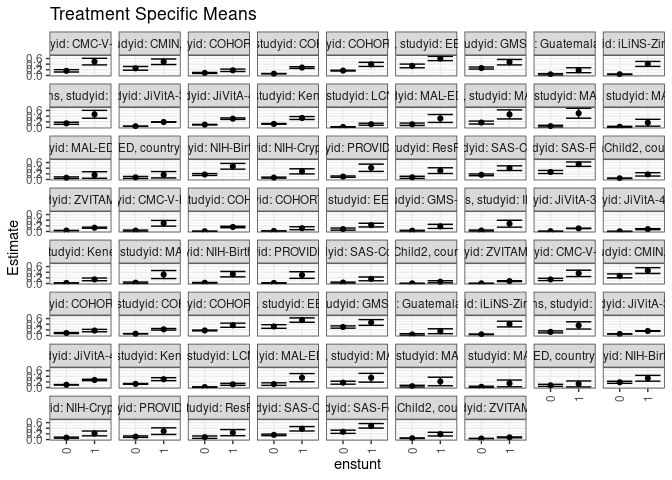

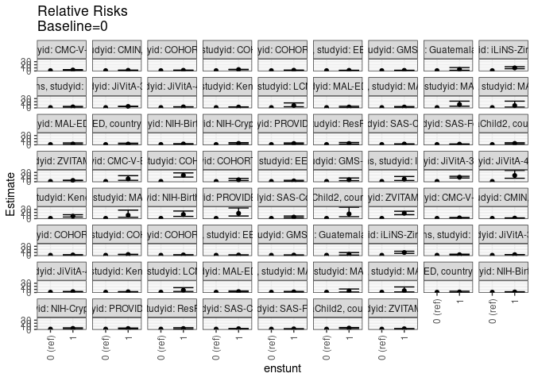

[figure not shown]

[figure not shown]

## Results Table

### Parameter: TSM

| agecat | studyid | country | intervention_level | baseline_level | estimate | ci_lower | ci_upper |
| --- | --- | --- | --- | --- | --- | --- | --- |
| 0-24 months | CMC-V-BCS-2002 | INDIA | 0 | NA | 0.1629639 | 0.1206974 | 0.2052304 |
| 0-24 months | CMC-V-BCS-2002 | INDIA | 1 | NA | 0.4894930 | 0.3721604 | 0.6068256 |
| 0-24 months | CMIN | BANGLADESH | 0 | NA | 0.2510704 | 0.1847285 | 0.3174123 |
| 0-24 months | CMIN | BANGLADESH | 1 | NA | 0.4841924 | 0.3861683 | 0.5822165 |
| 0-24 months | COHORTS | GUATEMALA | 0 | NA | 0.0878332 | 0.0705124 | 0.1051539 |
| 0-24 months | COHORTS | GUATEMALA | 1 | NA | 0.1816592 | 0.1391148 | 0.2242035 |
| 0-24 months | COHORTS | INDIA | 0 | NA | 0.0614577 | 0.0556429 | 0.0672725 |
| 0-24 months | COHORTS | INDIA | 1 | NA | 0.2784465 | 0.2487736 | 0.3081195 |
| 0-24 months | COHORTS | PHILIPPINES | 0 | NA | 0.1701508 | 0.1564241 | 0.1838774 |
| 0-24 months | COHORTS | PHILIPPINES | 1 | NA | 0.3916039 | 0.3192823 | 0.4639254 |
| 0-24 months | EE | PAKISTAN | 0 | NA | 0.3363064 | 0.2719678 | 0.4006451 |
| 0-24 months | EE | PAKISTAN | 1 | NA | 0.5993926 | 0.5236974 | 0.6750878 |
| 0-24 months | GMS-Nepal | NEPAL | 0 | NA | 0.2606914 | 0.2248476 | 0.2965352 |
| 0-24 months | GMS-Nepal | NEPAL | 1 | NA | 0.4697156 | 0.3734617 | 0.5659696 |
| 0-24 months | Guatemala BSC | GUATEMALA | 0 | NA | 0.0376569 | 0.0134841 | 0.0618297 |
| 0-24 months | Guatemala BSC | GUATEMALA | 1 | NA | 0.1842105 | 0.0969178 | 0.2715032 |
| 0-24 months | iLiNS-Zinc | BURKINA FASO | 0 | NA | 0.0409688 | 0.0302695 | 0.0516680 |
| 0-24 months | iLiNS-Zinc | BURKINA FASO | 1 | NA | 0.4076855 | 0.3195705 | 0.4958005 |
| 0-24 months | IRC | INDIA | 0 | NA | 0.1464378 | 0.1096892 | 0.1831864 |
| 0-24 months | IRC | INDIA | 1 | NA | 0.4659400 | 0.3269971 | 0.6048829 |
| 0-24 months | JiVitA-3 | BANGLADESH | 0 | NA | 0.0415287 | 0.0383852 | 0.0446722 |
| 0-24 months | JiVitA-3 | BANGLADESH | 1 | NA | 0.1920396 | 0.1827816 | 0.2012977 |
| 0-24 months | JiVitA-4 | BANGLADESH | 0 | NA | 0.0986169 | 0.0878571 | 0.1093768 |
| 0-24 months | JiVitA-4 | BANGLADESH | 1 | NA | 0.3107577 | 0.2844908 | 0.3370247 |
| 0-24 months | Keneba | GAMBIA | 0 | NA | 0.1254715 | 0.1126915 | 0.1382516 |
| 0-24 months | Keneba | GAMBIA | 1 | NA | 0.3344607 | 0.2828065 | 0.3861149 |
| 0-24 months | LCNI-5 | MALAWI | 0 | NA | 0.0150659 | 0.0046987 | 0.0254331 |
| 0-24 months | LCNI-5 | MALAWI | 1 | NA | 0.1132686 | 0.0779114 | 0.1486258 |
| 0-24 months | MAL-ED | BANGLADESH | 0 | NA | 0.1113893 | 0.0692778 | 0.1535008 |
| 0-24 months | MAL-ED | BANGLADESH | 1 | NA | 0.3179219 | 0.1769023 | 0.4589414 |

[output cut: 110 more lines]

### Parameter: E(Y)

| agecat | studyid | country | intervention_level | baseline_level | estimate | ci_lower | ci_upper |
| --- | --- | --- | --- | --- | --- | --- | --- |
| 0-24 months | CMC-V-BCS-2002 | INDIA | NA | NA | 0.2305630 | 0.1877616 | 0.2733644 |
| 0-24 months | CMIN | BANGLADESH | NA | NA | 0.3394834 | 0.2830004 | 0.3959663 |
| 0-24 months | COHORTS | GUATEMALA | NA | NA | 0.1104522 | 0.0937191 | 0.1271852 |
| 0-24 months | COHORTS | INDIA | NA | NA | 0.0894353 | 0.0829338 | 0.0959368 |
| 0-24 months | COHORTS | PHILIPPINES | NA | NA | 0.1839080 | 0.1701456 | 0.1976705 |
| 0-24 months | EE | PAKISTAN | NA | NA | 0.4485488 | 0.3984116 | 0.4986861 |
| 0-24 months | GMS-Nepal | NEPAL | NA | NA | 0.2944606 | 0.2603274 | 0.3285938 |
| 0-24 months | Guatemala BSC | GUATEMALA | NA | NA | 0.0730159 | 0.0442400 | 0.1017917 |
| 0-24 months | iLiNS-Zinc | BURKINA FASO | NA | NA | 0.1246554 | 0.1041227 | 0.1451882 |
| 0-24 months | IRC | INDIA | NA | NA | 0.1853659 | 0.1477057 | 0.2230261 |
| 0-24 months | JiVitA-3 | BANGLADESH | NA | NA | 0.0888460 | 0.0849398 | 0.0927521 |
| 0-24 months | JiVitA-4 | BANGLADESH | NA | NA | 0.1613377 | 0.1500062 | 0.1726692 |
| 0-24 months | Keneba | GAMBIA | NA | NA | 0.1483007 | 0.1353925 | 0.1612090 |
| 0-24 months | LCNI-5 | MALAWI | NA | NA | 0.0511905 | 0.0362780 | 0.0661030 |
| 0-24 months | MAL-ED | BANGLADESH | NA | NA | 0.1482890 | 0.1052563 | 0.1913216 |
| 0-24 months | MAL-ED | INDIA | NA | NA | 0.2151394 | 0.1642023 | 0.2660766 |
| 0-24 months | MAL-ED | NEPAL | NA | NA | 0.0916667 | 0.0550838 | 0.1282495 |
| 0-24 months | MAL-ED | PERU | NA | NA | 0.0397351 | 0.0176679 | 0.0618023 |
| 0-24 months | MAL-ED | SOUTH AFRICA | NA | NA | 0.0737179 | 0.0446760 | 0.1027599 |
| 0-24 months | MAL-ED | TANZANIA, UNITED REPUBLIC OF | NA | NA | 0.0881226 | 0.0536659 | 0.1225793 |
| 0-24 months | NIH-Birth | BANGLADESH | NA | NA | 0.2195513 | 0.1870467 | 0.2520558 |
| 0-24 months | NIH-Crypto | BANGLADESH | NA | NA | 0.0936675 | 0.0729118 | 0.1144233 |
| 0-24 months | PROVIDE | BANGLADESH | NA | NA | 0.1285714 | 0.1037574 | 0.1533855 |
| 0-24 months | ResPak | PAKISTAN | NA | NA | 0.1478873 | 0.1065284 | 0.1892462 |
| 0-24 months | SAS-CompFeed | INDIA | NA | NA | 0.2319894 | 0.1917264 | 0.2722524 |
| 0-24 months | SAS-FoodSuppl | INDIA | NA | NA | 0.3708134 | 0.3244530 | 0.4171738 |
| 0-24 months | TanzaniaChild2 | TANZANIA, UNITED REPUBLIC OF | NA | NA | 0.0496661 | 0.0409652 | 0.0583670 |
| 0-24 months | ZVITAMBO | ZIMBABWE | NA | NA | 0.0423899 | 0.0390454 | 0.0457344 |
| 0-6 months | CMC-V-BCS-2002 | INDIA | NA | NA | 0.0842391 | 0.0558231 | 0.1126551 |
| 0-6 months | COHORTS | INDIA | NA | NA | 0.0259576 | 0.0222658 | 0.0296495 |
| 0-6 months | COHORTS | PHILIPPINES | NA | NA | 0.0236531 | 0.0182537 | 0.0290525 |
| 0-6 months | EE | PAKISTAN | NA | NA | 0.1503958 | 0.1143605 | 0.1864311 |
| 0-6 months | GMS-Nepal | NEPAL | NA | NA | 0.0524781 | 0.0357793 | 0.0691770 |
| 0-6 months | IRC | INDIA | NA | NA | 0.0611247 | 0.0378797 | 0.0843697 |
| 0-6 months | JiVitA-3 | BANGLADESH | NA | NA | 0.0396778 | 0.0371765 | 0.0421791 |
| 0-6 months | JiVitA-4 | BANGLADESH | NA | NA | 0.0265122 | 0.0211694 | 0.0318550 |
| 0-6 months | Keneba | GAMBIA | NA | NA | 0.0284322 | 0.0218657 | 0.0349987 |
| 0-6 months | MAL-ED | INDIA | NA | NA | 0.0756972 | 0.0429084 | 0.1084860 |
| 0-6 months | NIH-Birth | BANGLADESH | NA | NA | 0.0723473 | 0.0519719 | 0.0927227 |
| 0-6 months | PROVIDE | BANGLADESH | NA | NA | 0.0428571 | 0.0278427 | 0.0578716 |
| 0-6 months | SAS-CompFeed | INDIA | NA | NA | 0.0704787 | 0.0478990 | 0.0930584 |
| 0-6 months | TanzaniaChild2 | TANZANIA, UNITED REPUBLIC OF | NA | NA | 0.0079299 | 0.0043777 | 0.0114821 |
| 0-6 months | ZVITAMBO | ZIMBABWE | NA | NA | 0.0120612 | 0.0102430 | 0.0138795 |
| 6-24 months | CMC-V-BCS-2002 | INDIA | NA | NA | 0.1876676 | 0.1479906 | 0.2273445 |
| 6-24 months | CMIN | BANGLADESH | NA | NA | 0.3426295 | 0.2837999 | 0.4014590 |
| 6-24 months | COHORTS | GUATEMALA | NA | NA | 0.1116585 | 0.0939639 | 0.1293530 |
| 6-24 months | COHORTS | INDIA | NA | NA | 0.0831652 | 0.0766672 | 0.0896632 |
| 6-24 months | COHORTS | PHILIPPINES | NA | NA | 0.1908832 | 0.1763448 | 0.2054216 |
| 6-24 months | EE | PAKISTAN | NA | NA | 0.4193548 | 0.3691429 | 0.4695668 |
| 6-24 months | GMS-Nepal | NEPAL | NA | NA | 0.3254237 | 0.2875855 | 0.3632619 |
| 6-24 months | Guatemala BSC | GUATEMALA | NA | NA | 0.0649819 | 0.0359016 | 0.0940623 |
| 6-24 months | iLiNS-Zinc | BURKINA FASO | NA | NA | 0.1246554 | 0.1041227 | 0.1451882 |
| 6-24 months | IRC | INDIA | NA | NA | 0.1560976 | 0.1209228 | 0.1912723 |
| 6-24 months | JiVitA-3 | BANGLADESH | NA | NA | 0.0869213 | 0.0822621 | 0.0915805 |
| 6-24 months | JiVitA-4 | BANGLADESH | NA | NA | 0.1477252 | 0.1371297 | 0.1583206 |
| 6-24 months | Keneba | GAMBIA | NA | NA | 0.1469835 | 0.1337108 | 0.1602563 |
| 6-24 months | LCNI-5 | MALAWI | NA | NA | 0.0520581 | 0.0368996 | 0.0672166 |
| 6-24 months | MAL-ED | BANGLADESH | NA | NA | 0.1464435 | 0.1015265 | 0.1913605 |
| 6-24 months | MAL-ED | INDIA | NA | NA | 0.2000000 | 0.1487493 | 0.2512507 |
| 6-24 months | MAL-ED | NEPAL | NA | NA | 0.0680851 | 0.0358110 | 0.1003592 |
| 6-24 months | MAL-ED | PERU | NA | NA | 0.0407407 | 0.0171167 | 0.0643648 |
| 6-24 months | MAL-ED | TANZANIA, UNITED REPUBLIC OF | NA | NA | 0.0857143 | 0.0505889 | 0.1208396 |
| 6-24 months | NIH-Birth | BANGLADESH | NA | NA | 0.2103321 | 0.1759902 | 0.2446740 |
| 6-24 months | NIH-Crypto | BANGLADESH | NA | NA | 0.0863014 | 0.0659171 | 0.1066856 |
| 6-24 months | PROVIDE | BANGLADESH | NA | NA | 0.1221498 | 0.0962275 | 0.1480722 |
| 6-24 months | ResPak | PAKISTAN | NA | NA | 0.1313559 | 0.0881682 | 0.1745436 |
| 6-24 months | SAS-CompFeed | INDIA | NA | NA | 0.2260619 | 0.1909133 | 0.2612105 |
| 6-24 months | SAS-FoodSuppl | INDIA | NA | NA | 0.3615960 | 0.3145115 | 0.4086805 |
| 6-24 months | TanzaniaChild2 | TANZANIA, UNITED REPUBLIC OF | NA | NA | 0.0560238 | 0.0459853 | 0.0660623 |
| 6-24 months | ZVITAMBO | ZIMBABWE | NA | NA | 0.0410617 | 0.0373214 | 0.0448020 |

### Parameter: RR

| agecat | studyid | country | intervention_level | baseline_level | estimate | ci_lower | ci_upper |
| --- | --- | --- | --- | --- | --- | --- | --- |
| 0-24 months | CMC-V-BCS-2002 | INDIA | 0 | 0 | 1.000000 | 1.0000000 | 1.000000 |
| 0-24 months | CMC-V-BCS-2002 | INDIA | 1 | 0 | 3.003690 | 2.1049561 | 4.286147 |
| 0-24 months | CMIN | BANGLADESH | 0 | 0 | 1.000000 | 1.0000000 | 1.000000 |
| 0-24 months | CMIN | BANGLADESH | 1 | 0 | 1.928513 | 1.3816273 | 2.691870 |
| 0-24 months | COHORTS | GUATEMALA | 0 | 0 | 1.000000 | 1.0000000 | 1.000000 |
| 0-24 months | COHORTS | GUATEMALA | 1 | 0 | 2.068230 | 1.5220110 | 2.810476 |
| 0-24 months | COHORTS | INDIA | 0 | 0 | 1.000000 | 1.0000000 | 1.000000 |
| 0-24 months | COHORTS | INDIA | 1 | 0 | 4.530704 | 3.9309125 | 5.222014 |
| 0-24 months | COHORTS | PHILIPPINES | 0 | 0 | 1.000000 | 1.0000000 | 1.000000 |
| 0-24 months | COHORTS | PHILIPPINES | 1 | 0 | 2.301511 | 1.8827049 | 2.813480 |
| 0-24 months | EE | PAKISTAN | 0 | 0 | 1.000000 | 1.0000000 | 1.000000 |
| 0-24 months | EE | PAKISTAN | 1 | 0 | 1.782281 | 1.4182410 | 2.239765 |
| 0-24 months | GMS-Nepal | NEPAL | 0 | 0 | 1.000000 | 1.0000000 | 1.000000 |
| 0-24 months | GMS-Nepal | NEPAL | 1 | 0 | 1.801807 | 1.4079706 | 2.305808 |
| 0-24 months | Guatemala BSC | GUATEMALA | 0 | 0 | 1.000000 | 1.0000000 | 1.000000 |
| 0-24 months | Guatemala BSC | GUATEMALA | 1 | 0 | 4.891813 | 2.2026861 | 10.863933 |
| 0-24 months | iLiNS-Zinc | BURKINA FASO | 0 | 0 | 1.000000 | 1.0000000 | 1.000000 |
| 0-24 months | iLiNS-Zinc | BURKINA FASO | 1 | 0 | 9.951133 | 7.1982512 | 13.756820 |
| 0-24 months | IRC | INDIA | 0 | 0 | 1.000000 | 1.0000000 | 1.000000 |
| 0-24 months | IRC | INDIA | 1 | 0 | 3.181829 | 2.1529696 | 4.702360 |
| 0-24 months | JiVitA-3 | BANGLADESH | 0 | 0 | 1.000000 | 1.0000000 | 1.000000 |
| 0-24 months | JiVitA-3 | BANGLADESH | 1 | 0 | 4.624264 | 4.2441351 | 5.038439 |
| 0-24 months | JiVitA-4 | BANGLADESH | 0 | 0 | 1.000000 | 1.0000000 | 1.000000 |
| 0-24 months | JiVitA-4 | BANGLADESH | 1 | 0 | 3.151161 | 2.7510222 | 3.609500 |
| 0-24 months | Keneba | GAMBIA | 0 | 0 | 1.000000 | 1.0000000 | 1.000000 |
| 0-24 months | Keneba | GAMBIA | 1 | 0 | 2.665630 | 2.2161829 | 3.206227 |
| 0-24 months | LCNI-5 | MALAWI | 0 | 0 | 1.000000 | 1.0000000 | 1.000000 |
| 0-24 months | LCNI-5 | MALAWI | 1 | 0 | 7.518204 | 3.5314685 | 16.005633 |
| 0-24 months | MAL-ED | BANGLADESH | 0 | 0 | 1.000000 | 1.0000000 | 1.000000 |
| 0-24 months | MAL-ED | BANGLADESH | 1 | 0 | 2.854151 | 1.5981502 | 5.097253 |

[output cut: 110 more lines]

### Parameter: PAR

| agecat | studyid | country | intervention_level | baseline_level | estimate | ci_lower | ci_upper |
| --- | --- | --- | --- | --- | --- | --- | --- |
| 0-24 months | CMC-V-BCS-2002 | INDIA | 0 | NA | 0.0675991 | 0.0391389 | 0.0960593 |
| 0-24 months | CMIN | BANGLADESH | 0 | NA | 0.0884130 | 0.0419017 | 0.1349242 |
| 0-24 months | COHORTS | GUATEMALA | 0 | NA | 0.0226190 | 0.0115341 | 0.0337039 |
| 0-24 months | COHORTS | INDIA | 0 | NA | 0.0279776 | 0.0239052 | 0.0320500 |
| 0-24 months | COHORTS | PHILIPPINES | 0 | NA | 0.0137573 | 0.0090632 | 0.0184514 |
| 0-24 months | EE | PAKISTAN | 0 | NA | 0.1122424 | 0.0669071 | 0.1575777 |
| 0-24 months | GMS-Nepal | NEPAL | 0 | NA | 0.0337693 | 0.0165349 | 0.0510036 |
| 0-24 months | Guatemala BSC | GUATEMALA | 0 | NA | 0.0353590 | 0.0124312 | 0.0582868 |
| 0-24 months | iLiNS-Zinc | BURKINA FASO | 0 | NA | 0.0836867 | 0.0653509 | 0.1020224 |
| 0-24 months | IRC | INDIA | 0 | NA | 0.0389281 | 0.0186665 | 0.0591897 |
| 0-24 months | JiVitA-3 | BANGLADESH | 0 | NA | 0.0473173 | 0.0441655 | 0.0504690 |
| 0-24 months | JiVitA-4 | BANGLADESH | 0 | NA | 0.0627208 | 0.0542442 | 0.0711974 |
| 0-24 months | Keneba | GAMBIA | 0 | NA | 0.0228292 | 0.0165254 | 0.0291330 |
| 0-24 months | LCNI-5 | MALAWI | 0 | NA | 0.0361246 | 0.0221970 | 0.0500522 |
| 0-24 months | MAL-ED | BANGLADESH | 0 | NA | 0.0368997 | 0.0103233 | 0.0634761 |
| 0-24 months | MAL-ED | INDIA | 0 | NA | 0.0420557 | 0.0134943 | 0.0706171 |
| 0-24 months | MAL-ED | NEPAL | 0 | NA | 0.0451796 | 0.0187074 | 0.0716517 |
| 0-24 months | MAL-ED | PERU | 0 | NA | 0.0171787 | 0.0015689 | 0.0327885 |
| 0-24 months | MAL-ED | SOUTH AFRICA | 0 | NA | 0.0116742 | -0.0033029 | 0.0266512 |
| 0-24 months | MAL-ED | TANZANIA, UNITED REPUBLIC OF | 0 | NA | 0.0150632 | -0.0043938 | 0.0345203 |
| 0-24 months | NIH-Birth | BANGLADESH | 0 | NA | 0.0439306 | 0.0258334 | 0.0620279 |
| 0-24 months | NIH-Crypto | BANGLADESH | 0 | NA | 0.0293243 | 0.0158693 | 0.0427792 |
| 0-24 months | PROVIDE | BANGLADESH | 0 | NA | 0.0286980 | 0.0156193 | 0.0417768 |
| 0-24 months | ResPak | PAKISTAN | 0 | NA | 0.0722450 | 0.0380431 | 0.1064469 |
| 0-24 months | SAS-CompFeed | INDIA | 0 | NA | 0.0671384 | 0.0490140 | 0.0852627 |
| 0-24 months | SAS-FoodSuppl | INDIA | 0 | NA | 0.1058033 | 0.0668583 | 0.1447482 |
| 0-24 months | TanzaniaChild2 | TANZANIA, UNITED REPUBLIC OF | 0 | NA | 0.0093505 | 0.0050785 | 0.0136224 |
| 0-24 months | ZVITAMBO | ZIMBABWE | 0 | NA | 0.0101760 | 0.0082735 | 0.0120785 |
| 0-6 months | CMC-V-BCS-2002 | INDIA | 0 | NA | 0.0534172 | 0.0294136 | 0.0774209 |
| 0-6 months | COHORTS | INDIA | 0 | NA | 0.0182855 | 0.0151094 | 0.0214617 |
| 0-6 months | COHORTS | PHILIPPINES | 0 | NA | 0.0055195 | 0.0026762 | 0.0083628 |
| 0-6 months | EE | PAKISTAN | 0 | NA | 0.0658684 | 0.0323589 | 0.0993778 |
| 0-6 months | GMS-Nepal | NEPAL | 0 | NA | 0.0245136 | 0.0119796 | 0.0370477 |
| 0-6 months | IRC | INDIA | 0 | NA | 0.0280578 | 0.0114973 | 0.0446183 |
| 0-6 months | JiVitA-3 | BANGLADESH | 0 | NA | 0.0322299 | 0.0298551 | 0.0346048 |
| 0-6 months | JiVitA-4 | BANGLADESH | 0 | NA | 0.0224355 | 0.0173393 | 0.0275317 |
| 0-6 months | Keneba | GAMBIA | 0 | NA | 0.0105960 | 0.0062940 | 0.0148981 |
| 0-6 months | MAL-ED | INDIA | 0 | NA | 0.0471258 | 0.0200723 | 0.0741792 |
| 0-6 months | NIH-Birth | BANGLADESH | 0 | NA | 0.0476589 | 0.0305819 | 0.0647359 |
| 0-6 months | PROVIDE | BANGLADESH | 0 | NA | 0.0253672 | 0.0135539 | 0.0371805 |
| 0-6 months | SAS-CompFeed | INDIA | 0 | NA | 0.0374012 | 0.0202270 | 0.0545753 |
| 0-6 months | TanzaniaChild2 | TANZANIA, UNITED REPUBLIC OF | 0 | NA | 0.0038994 | 0.0013207 | 0.0064781 |
| 0-6 months | ZVITAMBO | ZIMBABWE | 0 | NA | 0.0073509 | 0.0058868 | 0.0088151 |
| 6-24 months | CMC-V-BCS-2002 | INDIA | 0 | NA | 0.0441003 | 0.0189886 | 0.0692120 |
| 6-24 months | CMIN | BANGLADESH | 0 | NA | 0.0711685 | 0.0237433 | 0.1185937 |
| 6-24 months | COHORTS | GUATEMALA | 0 | NA | 0.0228459 | 0.0107866 | 0.0349052 |
| 6-24 months | COHORTS | INDIA | 0 | NA | 0.0199267 | 0.0161905 | 0.0236629 |
| 6-24 months | COHORTS | PHILIPPINES | 0 | NA | 0.0114598 | 0.0068162 | 0.0161033 |
| 6-24 months | EE | PAKISTAN | 0 | NA | 0.0991396 | 0.0542069 | 0.1440724 |
| 6-24 months | GMS-Nepal | NEPAL | 0 | NA | 0.0243388 | 0.0061204 | 0.0425571 |
| 6-24 months | Guatemala BSC | GUATEMALA | 0 | NA | 0.0270673 | 0.0047788 | 0.0493557 |
| 6-24 months | iLiNS-Zinc | BURKINA FASO | 0 | NA | 0.0837093 | 0.0652286 | 0.1021901 |
| 6-24 months | IRC | INDIA | 0 | NA | 0.0281090 | 0.0098567 | 0.0463612 |
| 6-24 months | JiVitA-3 | BANGLADESH | 0 | NA | 0.0324709 | 0.0289475 | 0.0359944 |
| 6-24 months | JiVitA-4 | BANGLADESH | 0 | NA | 0.0511168 | 0.0433139 | 0.0589197 |
| 6-24 months | Keneba | GAMBIA | 0 | NA | 0.0181479 | 0.0119771 | 0.0243187 |
| 6-24 months | LCNI-5 | MALAWI | 0 | NA | 0.0366141 | 0.0224339 | 0.0507942 |
| 6-24 months | MAL-ED | BANGLADESH | 0 | NA | 0.0251543 | 0.0001716 | 0.0501370 |
| 6-24 months | MAL-ED | INDIA | 0 | NA | 0.0280076 | 0.0007020 | 0.0553131 |
| 6-24 months | MAL-ED | NEPAL | 0 | NA | 0.0197759 | 0.0000540 | 0.0394979 |
| 6-24 months | MAL-ED | PERU | 0 | NA | 0.0153170 | -0.0006592 | 0.0312932 |
| 6-24 months | MAL-ED | TANZANIA, UNITED REPUBLIC OF | 0 | NA | 0.0080444 | -0.0098296 | 0.0259183 |
| 6-24 months | NIH-Birth | BANGLADESH | 0 | NA | 0.0240920 | 0.0066526 | 0.0415314 |
| 6-24 months | NIH-Crypto | BANGLADESH | 0 | NA | 0.0192922 | 0.0071622 | 0.0314222 |
| 6-24 months | PROVIDE | BANGLADESH | 0 | NA | 0.0192450 | 0.0067760 | 0.0317141 |
| 6-24 months | ResPak | PAKISTAN | 0 | NA | 0.0465209 | 0.0126856 | 0.0803561 |
| 6-24 months | SAS-CompFeed | INDIA | 0 | NA | 0.0597123 | 0.0420900 | 0.0773347 |
| 6-24 months | SAS-FoodSuppl | INDIA | 0 | NA | 0.0859591 | 0.0465436 | 0.1253746 |
| 6-24 months | TanzaniaChild2 | TANZANIA, UNITED REPUBLIC OF | 0 | NA | 0.0092566 | 0.0045660 | 0.0139473 |
| 6-24 months | ZVITAMBO | ZIMBABWE | 0 | NA | 0.0041794 | 0.0024590 | 0.0058998 |

### Parameter: PAF

| agecat | studyid | country | intervention_level | baseline_level | estimate | ci_lower | ci_upper |
| --- | --- | --- | --- | --- | --- | --- | --- |
| 0-24 months | CMC-V-BCS-2002 | INDIA | 0 | NA | 0.2931914 | 0.1670029 | 0.4002640 |
| 0-24 months | CMIN | BANGLADESH | 0 | NA | 0.2604339 | 0.1111259 | 0.3846620 |
| 0-24 months | COHORTS | GUATEMALA | 0 | NA | 0.2047858 | 0.1022123 | 0.2956401 |
| 0-24 months | COHORTS | INDIA | 0 | NA | 0.3128252 | 0.2714903 | 0.3518148 |
| 0-24 months | COHORTS | PHILIPPINES | 0 | NA | 0.0748053 | 0.0493231 | 0.0996045 |
| 0-24 months | EE | PAKISTAN | 0 | NA | 0.2502345 | 0.1406373 | 0.3458544 |
| 0-24 months | GMS-Nepal | NEPAL | 0 | NA | 0.1146818 | 0.0547049 | 0.1708533 |
| 0-24 months | Guatemala BSC | GUATEMALA | 0 | NA | 0.4842641 | 0.1540456 | 0.6855818 |
| 0-24 months | iLiNS-Zinc | BURKINA FASO | 0 | NA | 0.6713440 | 0.5834229 | 0.7407089 |
| 0-24 months | IRC | INDIA | 0 | NA | 0.2100067 | 0.0986940 | 0.3075721 |
| 0-24 months | JiVitA-3 | BANGLADESH | 0 | NA | 0.5325765 | 0.5039160 | 0.5595811 |
| 0-24 months | JiVitA-4 | BANGLADESH | 0 | NA | 0.3887548 | 0.3394979 | 0.4343385 |
| 0-24 months | Keneba | GAMBIA | 0 | NA | 0.1539385 | 0.1118754 | 0.1940093 |
| 0-24 months | LCNI-5 | MALAWI | 0 | NA | 0.7056891 | 0.4538749 | 0.8413937 |
| 0-24 months | MAL-ED | BANGLADESH | 0 | NA | 0.2488363 | 0.0597111 | 0.3999218 |
| 0-24 months | MAL-ED | INDIA | 0 | NA | 0.1954810 | 0.0565951 | 0.3139204 |
| 0-24 months | MAL-ED | NEPAL | 0 | NA | 0.4928679 | 0.2094471 | 0.6746796 |
| 0-24 months | MAL-ED | PERU | 0 | NA | 0.4323308 | 0.0107995 | 0.6742336 |
| 0-24 months | MAL-ED | SOUTH AFRICA | 0 | NA | 0.1583624 | -0.0606925 | 0.3321780 |
| 0-24 months | MAL-ED | TANZANIA, UNITED REPUBLIC OF | 0 | NA | 0.1709351 | -0.0708039 | 0.3581004 |
| 0-24 months | NIH-Birth | BANGLADESH | 0 | NA | 0.2000929 | 0.1166313 | 0.2756689 |
| 0-24 months | NIH-Crypto | BANGLADESH | 0 | NA | 0.3130675 | 0.1716898 | 0.4303145 |
| 0-24 months | PROVIDE | BANGLADESH | 0 | NA | 0.2232069 | 0.1223360 | 0.3124846 |
| 0-24 months | ResPak | PAKISTAN | 0 | NA | 0.4885140 | 0.2491723 | 0.6515607 |
| 0-24 months | SAS-CompFeed | INDIA | 0 | NA | 0.2894027 | 0.2318415 | 0.3426506 |
| 0-24 months | SAS-FoodSuppl | INDIA | 0 | NA | 0.2853276 | 0.1734712 | 0.3820461 |
| 0-24 months | TanzaniaChild2 | TANZANIA, UNITED REPUBLIC OF | 0 | NA | 0.1882664 | 0.1042103 | 0.2644351 |
| 0-24 months | ZVITAMBO | ZIMBABWE | 0 | NA | 0.2400569 | 0.1979945 | 0.2799134 |
| 0-6 months | CMC-V-BCS-2002 | INDIA | 0 | NA | 0.6341140 | 0.3743864 | 0.7860140 |
| 0-6 months | COHORTS | INDIA | 0 | NA | 0.7044382 | 0.6239451 | 0.7677020 |
| 0-6 months | COHORTS | PHILIPPINES | 0 | NA | 0.2333518 | 0.1170763 | 0.3343146 |
| 0-6 months | EE | PAKISTAN | 0 | NA | 0.4379670 | 0.1947331 | 0.6077311 |
| 0-6 months | GMS-Nepal | NEPAL | 0 | NA | 0.4671211 | 0.2389127 | 0.6269023 |
| 0-6 months | IRC | INDIA | 0 | NA | 0.4590255 | 0.1942387 | 0.6367989 |
| 0-6 months | JiVitA-3 | BANGLADESH | 0 | NA | 0.8122913 | 0.7783514 | 0.8410342 |
| 0-6 months | JiVitA-4 | BANGLADESH | 0 | NA | 0.8462344 | 0.7405288 | 0.9088768 |
| 0-6 months | Keneba | GAMBIA | 0 | NA | 0.3726774 | 0.2329252 | 0.4869684 |
| 0-6 months | MAL-ED | INDIA | 0 | NA | 0.6225564 | 0.2796741 | 0.8022233 |
| 0-6 months | NIH-Birth | BANGLADESH | 0 | NA | 0.6587515 | 0.4660294 | 0.7819159 |
| 0-6 months | PROVIDE | BANGLADESH | 0 | NA | 0.5919018 | 0.3546646 | 0.7419263 |
| 0-6 months | SAS-CompFeed | INDIA | 0 | NA | 0.5306732 | 0.3286185 | 0.6719188 |
| 0-6 months | TanzaniaChild2 | TANZANIA, UNITED REPUBLIC OF | 0 | NA | 0.4917387 | 0.1849308 | 0.6830582 |
| 0-6 months | ZVITAMBO | ZIMBABWE | 0 | NA | 0.6094680 | 0.5208251 | 0.6817128 |
| 6-24 months | CMC-V-BCS-2002 | INDIA | 0 | NA | 0.2349916 | 0.0955222 | 0.3529549 |
| 6-24 months | CMIN | BANGLADESH | 0 | NA | 0.2077127 | 0.0576562 | 0.3338745 |
| 6-24 months | COHORTS | GUATEMALA | 0 | NA | 0.2046054 | 0.0934565 | 0.3021266 |
| 6-24 months | COHORTS | INDIA | 0 | NA | 0.2396044 | 0.1972054 | 0.2797641 |
| 6-24 months | COHORTS | PHILIPPINES | 0 | NA | 0.0600355 | 0.0356447 | 0.0838095 |
| 6-24 months | EE | PAKISTAN | 0 | NA | 0.2364099 | 0.1205386 | 0.3370149 |
| 6-24 months | GMS-Nepal | NEPAL | 0 | NA | 0.0747910 | 0.0172675 | 0.1289474 |
| 6-24 months | Guatemala BSC | GUATEMALA | 0 | NA | 0.4165350 | 0.0363123 | 0.6467410 |
| 6-24 months | iLiNS-Zinc | BURKINA FASO | 0 | NA | 0.6715256 | 0.5836053 | 0.7408818 |
| 6-24 months | IRC | INDIA | 0 | NA | 0.1800730 | 0.0597281 | 0.2850151 |
| 6-24 months | JiVitA-3 | BANGLADESH | 0 | NA | 0.3735671 | 0.3360521 | 0.4089623 |
| 6-24 months | JiVitA-4 | BANGLADESH | 0 | NA | 0.3460262 | 0.2945351 | 0.3937590 |
| 6-24 months | Keneba | GAMBIA | 0 | NA | 0.1234691 | 0.0815334 | 0.1634900 |
| 6-24 months | LCNI-5 | MALAWI | 0 | NA | 0.7033312 | 0.4495815 | 0.8400992 |
| 6-24 months | MAL-ED | BANGLADESH | 0 | NA | 0.1717680 | -0.0096992 | 0.3206211 |
| 6-24 months | MAL-ED | INDIA | 0 | NA | 0.1400378 | -0.0047653 | 0.2639723 |
| 6-24 months | MAL-ED | NEPAL | 0 | NA | 0.2904589 | -0.0216670 | 0.5072284 |
| 6-24 months | MAL-ED | PERU | 0 | NA | 0.3759630 | -0.0586014 | 0.6321353 |
| 6-24 months | MAL-ED | TANZANIA, UNITED REPUBLIC OF | 0 | NA | 0.0938511 | -0.1368976 | 0.2777663 |
| 6-24 months | NIH-Birth | BANGLADESH | 0 | NA | 0.1145427 | 0.0288861 | 0.1926439 |
| 6-24 months | NIH-Crypto | BANGLADESH | 0 | NA | 0.2235447 | 0.0799089 | 0.3447574 |
| 6-24 months | PROVIDE | BANGLADESH | 0 | NA | 0.1575525 | 0.0535939 | 0.2500918 |
| 6-24 months | ResPak | PAKISTAN | 0 | NA | 0.3541590 | 0.0697386 | 0.5516200 |
| 6-24 months | SAS-CompFeed | INDIA | 0 | NA | 0.2641415 | 0.2015410 | 0.3218339 |
| 6-24 months | SAS-FoodSuppl | INDIA | 0 | NA | 0.2377214 | 0.1211019 | 0.3388668 |
| 6-24 months | TanzaniaChild2 | TANZANIA, UNITED REPUBLIC OF | 0 | NA | 0.1652268 | 0.0824309 | 0.2405518 |
| 6-24 months | ZVITAMBO | ZIMBABWE | 0 | NA | 0.1017834 | 0.0599247 | 0.1417783 |